# Diversity of treeline epiphytes

EdithClemente

2025-09-29

Packages

```r
knitr::opts_chunk$set(echo = TRUE, warning = FALSE, message = FALSE)
library(dplyr)
```

```r
library(ggplot2)
library(vegan)
library(hillR)
library(tidyverse)
library(iNEXT)
library(patchwork)   # para combinar gráficos
library(betapart)
```

```r
setwd("C:/Users/edith clemente arena/Desktop/EPIFITAS -GRADIENTE/treeline-epiphytes/treeline-epiphytes")
data <- read.csv("estrucPOB.csv", header = TRUE, sep = ";", stringsAsFactors = FALSE)
str(data)      # Estructura de la base de datos
```

```
## 'data.frame':    4989 obs. of  21 variables:
##  $ plot         : chr  "ACJ-01" "ACJ-01" "ACJ-01" "ACJ-01" ...
##  $ elevation    : int  3537 3537 3537 3537 3537 3537 3537 3537 3537 3537 ...
##  $ subplot      : int  9 9 9 9 9 9 9 9 9 9 ...
##  $ treecod      : int  313 313 313 313 313 313 313 313 313 313 ...
##  $ forof        : chr  "ACJ-01_313" "ACJ-01_313" "ACJ-01_313" "ACJ-01_313" ...
##  $ tree_name    : chr  "Sessea dependens" "Sessea dependens" "Sessea dependens" "Sessea dependens" ...
##  $ genera_tree  : chr  "Sessea" "Sessea" "Sessea" "Sessea" ...
##  $ dap          : num  15 15 15 15 15 15 15 15 15 15 ...
##  $ height       : num  9 9 9 9 9 9 9 9 9 9 ...
##  $ tree_str     : chr  "I" "II" "III" "IV" ...
##  $ name_epi     : chr  "Microgramma 1" "Microgramma 1" "Microgramma 1" "Elaphoglossum 1" ...
##  $ morphospe    : chr  "Campyloneurum densifolium" "Campyloneurum densifolium" "Campyloneurum densifolium" "Elaphoglossum vulcanicum" ...
##  $ genera_epi   : chr  "Campyloneurum" "Campyloneurum" "Campyloneurum" "Elaphoglossum" ...
##  $ family       : chr  "Polypodiaceae" "Polypodiaceae" "Polypodiaceae" "Dryopteridaceae" ...
##  $ taxon        : chr  "Pteridophyta" "Pteridophyta" "Pteridophyta" "Pteridophyta" ...
##  $ foro_h       : num  1.5 3 5 8 7.5 7.1 4.5 4 7 8 ...
##  $ life_stage   : chr  "adulto" "adulto" "adulto" "adulto" ...
##  $ l_leaf_stem  : num  25 23.4 42.9 15.9 13.2 11.2 22.8 9 19.2 9.3 ...
##  $ n_shoots_leaf: int  12 22 32 14 10 3 2 1 4 2 ...
##  $ reprod_stage : chr  "esteril" "esteril" "reproductivo" "esteril" ...
##  $ herbi        : int  1 1 1 2 1 1 0 0 0 0 ...
```

```r
head(data)
```

```
##     plot elevation subplot treecod      forof        tree_name genera_tree dap
## 1 ACJ-01      3537       9     313 ACJ-01_313 Sessea dependens      Sessea  15
## 2 ACJ-01      3537       9     313 ACJ-01_313 Sessea dependens      Sessea  15
## 3 ACJ-01      3537       9     313 ACJ-01_313 Sessea dependens      Sessea  15
## 4 ACJ-01      3537       9     313 ACJ-01_313 Sessea dependens      Sessea  15
## 5 ACJ-01      3537       9     313 ACJ-01_313 Sessea dependens      Sessea  15
## 6 ACJ-01      3537       9     313 ACJ-01_313 Sessea dependens      Sessea  15
##   height tree_str        name_epi                 morphospe    genera_epi
## 1      9        I   Microgramma 1 Campyloneurum densifolium Campyloneurum
## 2      9       II   Microgramma 1 Campyloneurum densifolium Campyloneurum
## 3      9      III   Microgramma 1 Campyloneurum densifolium Campyloneurum
## 4      9       IV Elaphoglossum 1  Elaphoglossum vulcanicum Elaphoglossum
## 5      9       IV Elaphoglossum 1  Elaphoglossum vulcanicum Elaphoglossum
## 6      9       IV Elaphoglossum 1  Elaphoglossum vulcanicum Elaphoglossum
##            family        taxon foro_h life_stage l_leaf_stem n_shoots_leaf
## 1   Polypodiaceae Pteridophyta    1.5     adulto        25.0            12
## 2   Polypodiaceae Pteridophyta    3.0     adulto        23.4            22
## 3   Polypodiaceae Pteridophyta    5.0     adulto        42.9            32
## 4 Dryopteridaceae Pteridophyta    8.0     adulto        15.9            14
## 5 Dryopteridaceae Pteridophyta    7.5     adulto        13.2            10
## 6 Dryopteridaceae Pteridophyta    7.1     adulto        11.2             3
##   reprod_stage herbi
## 1      esteril     1
## 2      esteril     1
## 3 reproductivo     1
## 4      esteril     2
## 5      esteril     1
## 6      esteril     1
```

TABLES species richness and abundance by plots - elevations

```r
RIQPLOT <- data %>%
  group_by(plot, elevation) %>%              # Agrupa por árbol
  summarise(RIQUEZA = n_distinct(morphospe)) # Cuenta especies únicas
RIQPLOT
```

```
## # A tibble: 4 × 3
## # Groups:   plot [4]
##   plot   elevation RIQUEZA
##   <chr>      <int>   <int>
## 1 ACJ-01      3537      51
## 2 APK-01      3625      45
## 3 TRU-01      3402      88
## 4 TRU-02      3261      91
```

```r
ABUNDPLOT <- data %>%
  group_by(plot, elevation) %>%
  summarise(ABUNDANCIA = n())     #Cuenta numero de individuos
ABUNDPLOT
```

```
## # A tibble: 4 × 3
## # Groups:   plot [4]
##   plot   elevation ABUNDANCIA
##   <chr>      <int>      <int>
## 1 ACJ-01      3537        817
## 2 APK-01      3625        992
## 3 TRU-01      3402       1440
## 4 TRU-02      3261       1740
```

TABLES species richness and abundance by forophytes

```r
DIVERFORO <- data %>%
  group_by(forof) %>%
  summarise(
    RIQUEZA    = n_distinct(morphospe),  # especies únicas
    ABUNDANCIA = n()                     # número de individuos (filas)
  )
DIVERFORO
```

```
## # A tibble: 186 × 3
##    forof      RIQUEZA ABUNDANCIA
##    <chr>        <int>      <int>
##  1 ACJ-01_313       6         15
##  2 ACJ-01_314       4         11
##  3 ACJ-01_315       8         17
##  4 ACJ-01_316       6         13
##  5 ACJ-01_317       3          5
##  6 ACJ-01_319       3          5
##  7 ACJ-01_321       6         11
##  8 ACJ-01_323       6         23
##  9 ACJ-01_325      15         71
## 10 ACJ-01_326       2          4
## # ℹ 176 more rows
```

```r
data_tree <- data %>%            #Tabla con datos del forofito
  group_by(forof) %>%
  distinct(forof, dap, plot, genera_tree, elevation)
data_tree
```

```
## # A tibble: 186 × 5
## # Groups:   forof [186]
##    forof         dap plot   genera_tree elevation
##    <chr>       <dbl> <chr>  <chr>           <int>
##  1 ACJ-01_313   15   ACJ-01 Sessea           3537
##  2 ACJ-01_317   26.5 ACJ-01 Symplocos        3537
##  3 ACJ-01_316   17.2 ACJ-01 Hedyosmum        3537
##  4 ACJ-01_315   50.8 ACJ-01 Polylepis        3537
##  5 ACJ-01_339   25.2 ACJ-01 Symplocos        3537
##  6 ACJ-01_314   28.5 ACJ-01 Hedyosmum        3537
##  7 ACJ-01_336   31.1 ACJ-01 Weinmannia       3537
##  8 ACJ-01_319   15.1 ACJ-01 Symplocos        3537
##  9 ACJ-01_4546  12.6 ACJ-01 Symplocos        3537
## 10 ACJ-01_321   15.7 ACJ-01 Weinmannia       3537
## # ℹ 176 more rows
```

```r
DIVERFORO <- DIVERFORO %>%          #juntar
  left_join(data_tree, by = "forof")
DIVERFORO
```

```
## # A tibble: 186 × 7
##    forof      RIQUEZA ABUNDANCIA   dap plot   genera_tree elevation
##    <chr>        <int>      <int> <dbl> <chr>  <chr>           <int>
##  1 ACJ-01_313       6         15  15   ACJ-01 Sessea           3537
##  2 ACJ-01_314       4         11  28.5 ACJ-01 Hedyosmum        3537
##  3 ACJ-01_315       8         17  50.8 ACJ-01 Polylepis        3537
##  4 ACJ-01_316       6         13  17.2 ACJ-01 Hedyosmum        3537
##  5 ACJ-01_317       3          5  26.5 ACJ-01 Symplocos        3537
##  6 ACJ-01_319       3          5  15.1 ACJ-01 Symplocos        3537
##  7 ACJ-01_321       6         11  15.7 ACJ-01 Weinmannia       3537
##  8 ACJ-01_323       6         23  28.3 ACJ-01 Weinmannia       3537
##  9 ACJ-01_325      15         71  51.8 ACJ-01 Weinmannia       3537
## 10 ACJ-01_326       2          4  12.5 ACJ-01 Saracha          3537
## # ℹ 176 more rows
```

GRAPHICS Graphic abundance by elevation

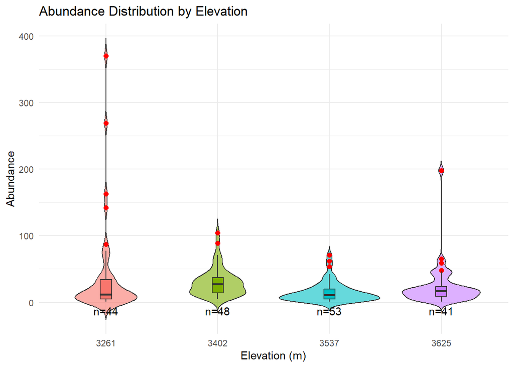

```r
counts <- DIVERFORO %>%
  group_by(elevation) %>%
  summarise(n = n_distinct(forof))

ggplot(DIVERFORO, aes(x = factor(elevation), y = ABUNDANCIA, fill = factor(elevation))) +
  geom_violin(trim = FALSE, alpha = 0.6) +
  geom_boxplot(width = 0.1, outlier.colour = "red", outlier.shape = 16, outlier.size = 2) +
  geom_text(
    data = counts,
    aes(x = factor(elevation), y = 0, label = paste0("n=", n)),
    vjust = 1.5, color = "black"
  ) +
  labs(
    title = "Abundance Distribution by Elevation",
    x = "Elevation (m)",
    y = "Abundance"
  ) +
  theme_minimal() +
  theme(legend.position = "none")
```

Graphic richness by elevation

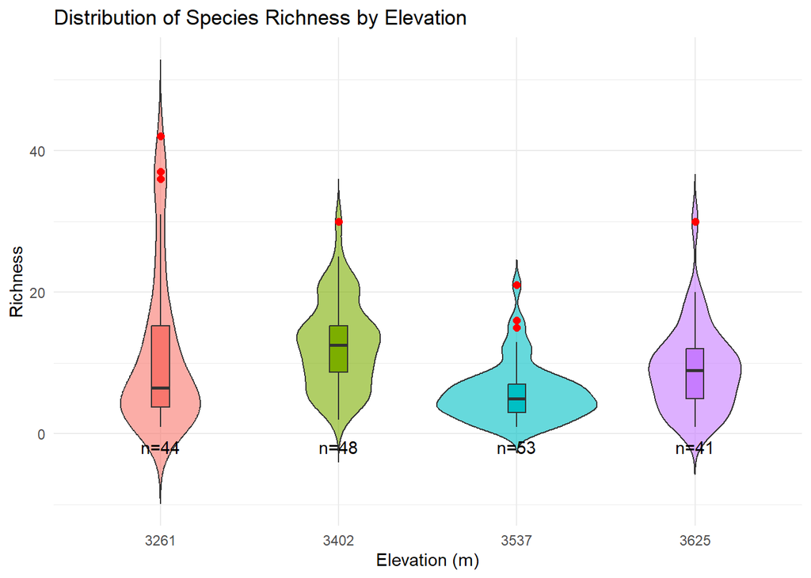

```r
ggplot(DIVERFORO, aes(x = factor(elevation), y = RIQUEZA, fill = factor(elevation))) +
  geom_violin(trim = FALSE, alpha = 0.6) +
  geom_boxplot(width = 0.1, outlier.colour = "red", outlier.shape = 16, outlier.size = 2) +
  geom_text(
    data = counts,
    aes(x = factor(elevation), y = 0, label = paste0("n=", n)),
    vjust = 1.5, color = "black"
  ) +
  labs(
    title = "Distribution of Species Richness by Elevation",
    x = "Elevation (m)",
    y = "Richness"
  ) +
  theme_minimal() +
  theme(legend.position = "none")
```

graphic conbined of ABUNDANCE and richness

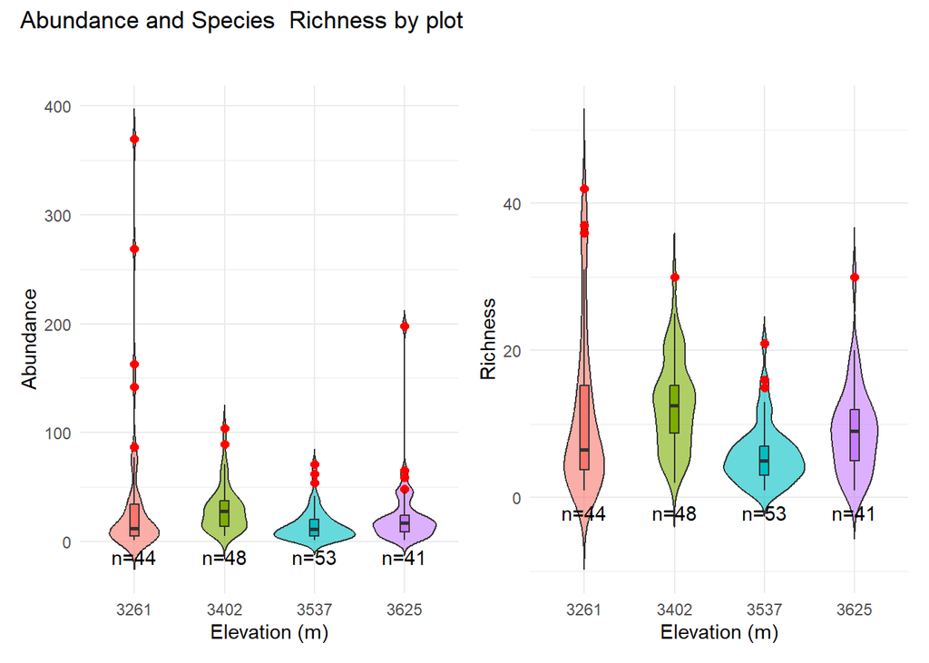

```r
# Calcular el número de especies únicas por elevación
counts <- DIVERFORO %>%
  group_by(elevation) %>%
  summarise(n = n_distinct(forof))

# --- Gráfico 1: Abundancia ---
g_abund <- ggplot(DIVERFORO, aes(x = factor(elevation), y = ABUNDANCIA, fill = factor(elevation))) +
  geom_violin(trim = FALSE, alpha = 0.6) +
  geom_boxplot(width = 0.1, outlier.colour = "red", outlier.shape = 16, outlier.size = 2) +
  geom_text(
    data = counts,
    aes(x = factor(elevation), y = 0, label = paste0("n=", n)),
    vjust = 1.5, color = "black"
  ) +
  labs(
    title = " ",
    x = "Elevation (m)",
    y = "Abundance"
  ) +
  theme_minimal() +
  theme(legend.position = "none")

# --- Gráfico 2: Riqueza ---
g_rich <- ggplot(DIVERFORO, aes(x = factor(elevation), y = RIQUEZA, fill = factor(elevation))) +
  geom_violin(trim = FALSE, alpha = 0.6) +
  geom_boxplot(width = 0.1, outlier.colour = "red", outlier.shape = 16, outlier.size = 2) +
  geom_text(
    data = counts,
    aes(x = factor(elevation), y = 0, label = paste0("n=", n)),
    vjust = 1.5, color = "black"
  ) +
  labs(
    title = " ",
    x = "Elevation (m)",
    y = "Richness"
  ) +
  theme_minimal() +
  theme(legend.position = "none")

# --- Combinar ambos gráficos ---
(g_abund + g_rich) +
  plot_annotation(
    title = "Abundance and Species  Richness by plot",
  )
```

Influence of DBH on epiphyte abundance

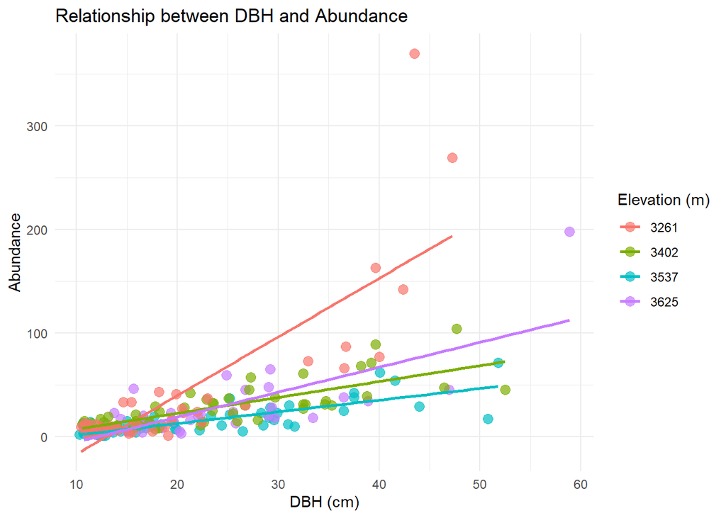

```r
ggplot(DIVERFORO, aes(x = dap, y = ABUNDANCIA, color = factor(elevation))) +
  geom_point(size = 3, alpha = 0.7) +
  geom_smooth(method = "lm", se = FALSE) +
  labs(
    title = "Relationship between DBH and Abundance",
    x = "DBH (cm)",
    y = "Abundance",
    color = "Elevation (m)"
  ) +
  theme_minimal()
```

Influence of DBH on epiphyte richness

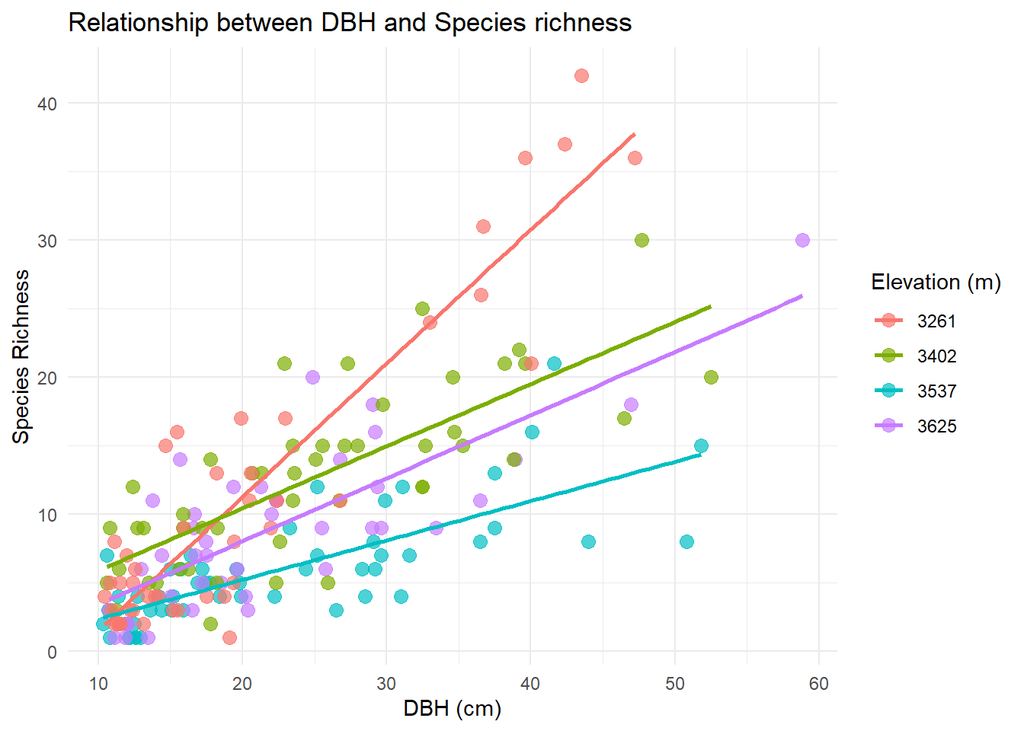

```r
ggplot(DIVERFORO, aes(x = dap, y = RIQUEZA, color = factor(elevation))) +
  geom_point(size = 3, alpha = 0.7) +
  geom_smooth(method = "lm", se = FALSE) +
  labs(
    title = "Relationship between DBH and Species richness",
    x = "DBH (cm)",
    y = "Species Richness",
    color = "Elevation (m)"
  ) +
  theme_minimal()
```

graphic conbined of DBH

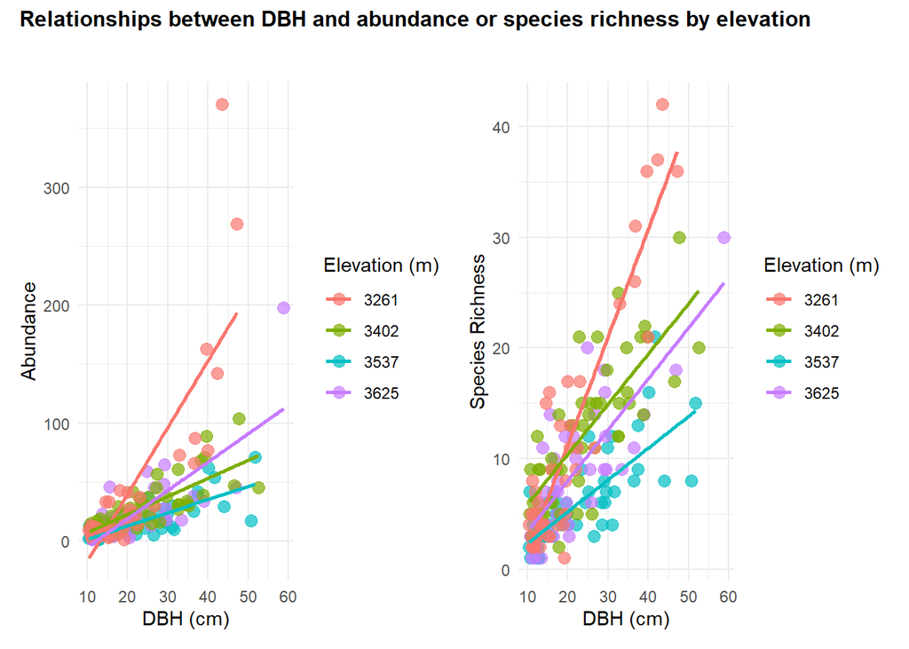

```r
# Cargar librería
library(patchwork)

# Gráfico 1: DBH vs Abundance
g3 <- ggplot(DIVERFORO, aes(x = dap, y = ABUNDANCIA, color = factor(elevation))) +
  geom_point(size = 3, alpha = 0.7) +
  geom_smooth(method = "lm", se = FALSE) +
  labs(
    title = " ",
    x = "DBH (cm)",
    y = "Abundance",
    color = "Elevation (m)"
  ) +
  theme_minimal()

# Gráfico 2: DBH vs Species Richness
g4 <- ggplot(DIVERFORO, aes(x = dap, y = RIQUEZA, color = factor(elevation))) +
  geom_point(size = 3, alpha = 0.7) +
  geom_smooth(method = "lm", se = FALSE) +
  labs(
    title = " ",
    x = "DBH (cm)",
    y = "Species Richness",
    color = "Elevation (m)"
  ) +
  theme_minimal()

# Unir ambos gráficos lado a lado
(g3 + g4) +
  plot_annotation(
    title = "Relationships between DBH and abundance or species richness by elevation",
        theme = theme(plot.title = element_text(face = "bold", size = 12))
  )
```

```r
##analisis de la influencia
library(dplyr)
library(broom)

mod_abund_R2 <- DIVERFORO %>%
  group_by(elevation) %>%
  do(glance(lm(ABUNDANCIA ~ dap, data = .))) %>%
  select(elevation, r.squared, p.value)
mod_abund_R2
```

```
## # A tibble: 4 × 3
## # Groups:   elevation [4]
##   elevation r.squared  p.value
##       <int>     <dbl>    <dbl>
## 1      3261     0.672 1.03e-11
## 2      3402     0.574 4.54e-10
## 3      3537     0.625 1.97e-12
## 4      3625     0.571 1.11e- 8
```

```r
mod_rich_R2 <- DIVERFORO %>%
  group_by(elevation) %>%
  do(glance(lm(RIQUEZA ~ dap, data = .))) %>%
  select(elevation, r.squared, p.value)
mod_rich_R2
```

```
## # A tibble: 4 × 3
## # Groups:   elevation [4]
##   elevation r.squared  p.value
##       <int>     <dbl>    <dbl>
## 1      3261     0.845 1.28e-18
## 2      3402     0.585 2.43e-10
## 3      3537     0.572 5.88e-11
## 4      3625     0.609 1.82e- 9
```

```r
resultados_abund <- DIVERFORO %>%
  group_by(elevation) %>%
  do(model = lm(ABUNDANCIA ~ dap, data = .)) %>%
  mutate(
    slope = coef(model)[2],
    p_value = summary(model)$coefficients[2,4],
    R2 = summary(model)$r.squared
  ) %>%
  select(elevation, slope, p_value, R2)

resultados_abund
```

```
## # A tibble: 4 × 4
## # Rowwise:
##   elevation slope  p_value    R2
##       <int> <dbl>    <dbl> <dbl>
## 1      3261  5.66 1.03e-11 0.672
## 2      3402  1.53 4.54e-10 0.574
## 3      3537  1.12 1.97e-12 0.625
## 4      3625  2.40 1.11e- 8 0.571
```

```r
resultados_riqu <- DIVERFORO %>%
  group_by(elevation) %>%
  do(model = lm(RIQUEZA ~ dap, data = .)) %>%
  mutate(
    slope = coef(model)[2],
    p_value = summary(model)$coefficients[2,4],
    R2 = summary(model)$r.squared
  ) %>%
  select(elevation, slope, p_value, R2)

resultados_riqu
```

```
## # A tibble: 4 × 4
## # Rowwise:
##   elevation slope  p_value    R2
##       <int> <dbl>    <dbl> <dbl>
## 1      3261 0.974 1.28e-18 0.845
## 2      3402 0.454 2.43e-10 0.585
## 3      3537 0.287 5.88e-11 0.572
## 4      3625 0.460 1.82e- 9 0.609
```

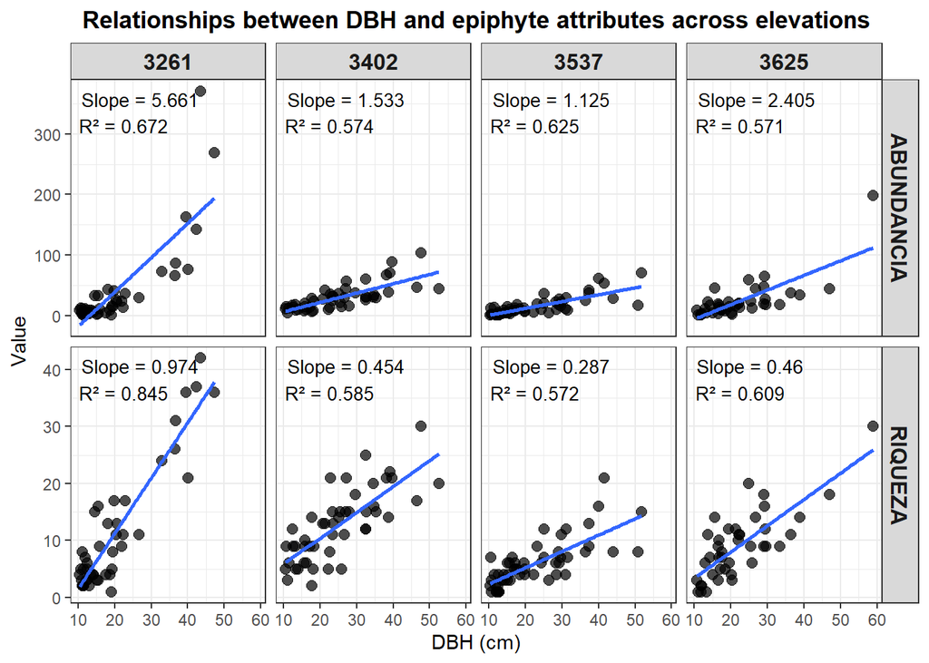

```r
DIVERFORO_long <- DIVERFORO %>%
  pivot_longer(cols = c(ABUNDANCIA, RIQUEZA),
               names_to = "atributo",
               values_to = "valor")
#####Grafico con facets por elevacion y sus datos
library(dplyr)
library(ggplot2)
library(purrr)
# Crear la tabla con pendientes y R2 por elevación y atributo
modelos <- DIVERFORO_long %>%
  group_by(elevation, atributo) %>%
  do({
    m <- lm(valor ~ dap, data = .)
    tibble(
      slope = coef(m)[2],
      r2 = summary(m)$r.squared
    )
  }) %>%
  mutate(
    label = paste0("Slope = ", round(slope, 3), "\nR² = ", round(r2, 3))
  )
# Hacer el gráfico con los textos en cada panel
ggplot(DIVERFORO_long, aes(x = dap, y = valor)) +
  geom_point(size = 2.5, alpha = 0.7) +
  geom_smooth(method = "lm", se = FALSE, linewidth = 1) +
  facet_grid(atributo ~ factor(elevation), scales = "free_y") +
  geom_text(
    data = modelos,
    aes(label = label),
    x = -Inf, y = Inf,
    hjust = -0.1, vjust = 1.3,
    size = 3.5,
    inherit.aes = FALSE
  ) +
  labs(
    title = "Relationships between DBH and epiphyte attributes across elevations",
    x = "DBH (cm)",
    y = "Value"
  ) +
  theme_bw() +
  theme(
    strip.text = element_text(face = "bold", size = 12),
    plot.title = element_text(face = "bold", size = 13, hjust = 0.5)
  )
```

Curva de acumulacion de especies

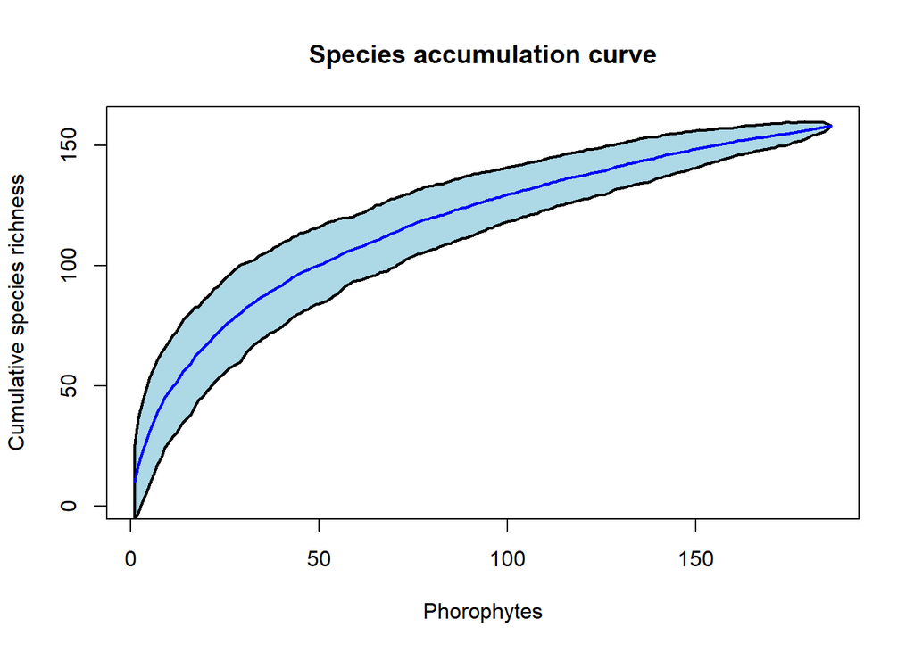

```r
###Todo las parcelas
data <- data %>%
  mutate(
    morphospe = iconv(morphospe, from = "UTF-8", to = "ASCII//TRANSLIT"),
    morphospe = gsub("[^-A-Za-z0-9_ ]", "", morphospe),  # quitar caracteres raros
    morphospe = gsub(" +", "_", morphospe)               # convertir varios espacios en _
  )
ABU <- data %>% #tabla de abundancias por plot/ELEVATION
  group_by(forof, morphospe) %>%
  summarise(ABUNDANCIA = n(), .groups = "drop") %>%
  arrange(forof, desc(ABUNDANCIA))
matr <- ABU %>% #matriz de abundancias
  pivot_wider( names_from = morphospe,
               values_from = ABUNDANCIA, values_fill = 0 )
matriz_sol <- as.data.frame(matr[, -1])
# 4. Calcular curva de acumulación
curva <- specaccum(matriz_sol, method = "random")
plot(curva,
     xlab = "Phorophytes",
     ylab = "Cumulative species richness",
     main = "Species accumulation curve",
     col = "blue", lwd = 2,
     ci.type = "polygon",
     ci.col = "lightblue")
```

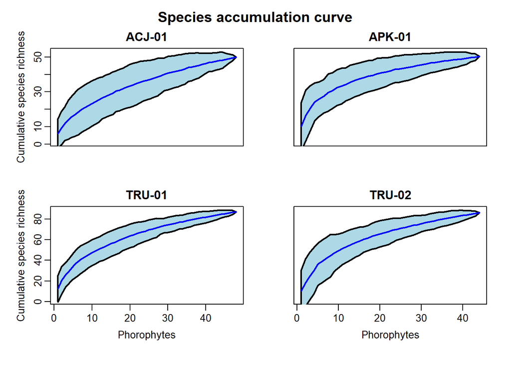

```r
###POR PLOT
library(dplyr)
library(tidyr)
library(vegan)
##ACJ-01
# 1. Filtrar solo ACJ-01 y calcular abundancia por árbol y especie
ABU_ACJ01 <- data %>%
  filter(plot == "ACJ-01") %>%
  group_by(forof, morphospe) %>%
  summarise(ABUNDANCIA = n(), .groups = "drop") %>%
  arrange(forof, desc(ABUNDANCIA))
# 2. Convertir a matriz (filas = forof, columnas = especies)
matriz_ACJ01 <- ABU_ACJ01 %>%
  pivot_wider(names_from = morphospe,
              values_from = ABUNDANCIA,
              values_fill = 0)
# 3. Eliminar columna forof (quedarse solo con abundancias)
matriz_solo_ab <- as.data.frame(matriz_ACJ01[, -1])
# 4. Calcular curva de acumulación
curva_ACJ01 <- specaccum(matriz_solo_ab, method = "random")
##APK-01
# 1. Filtrar solo APK-01 y calcular abundancia por árbol y especie
ABU_APK01 <- data %>%
  filter(plot == "APK-01") %>%
  group_by(forof, morphospe) %>%
  summarise(ABUNDANCIA = n(), .groups = "drop") %>%
  arrange(forof, desc(ABUNDANCIA))
# 2. Convertir a matriz (filas = forof, columnas = especies)
matriz_APK01 <- ABU_APK01 %>%
  pivot_wider(names_from = morphospe,
              values_from = ABUNDANCIA,
              values_fill = 0)
# 3. Eliminar columna forof (quedarse solo con abundancias)
matriz_solo_abK <- as.data.frame(matriz_APK01[, -1])
# 4. Calcular curva de acumulación
curva_APK01 <- specaccum(matriz_solo_abK, method = "random")
###TRU-1
# 1. Filtrar solo TRU-01 y calcular abundancia por árbol y especie
ABU_TRU01 <- data %>%
  filter(plot == "TRU-01") %>%
  group_by(forof, morphospe) %>%
  summarise(ABUNDANCIA = n(), .groups = "drop") %>%
  arrange(forof, desc(ABUNDANCIA))
# 2. Convertir a matriz (filas = forof, columnas = especies)
matriz_TRU01 <- ABU_TRU01 %>%
  pivot_wider(names_from = morphospe,
              values_from = ABUNDANCIA,
              values_fill = 0)
# 3. Eliminar columna forof (quedarse solo con abundancias)
matriz_solo_abT1 <- as.data.frame(matriz_TRU01[, -1])
# 4. Calcular curva de acumulación
curva_TRU01 <- specaccum(matriz_solo_abT1, method = "random")
####TRU-02
# 1. Filtrar solo APK-01 y calcular abundancia por árbol y especie
ABU_TRU02 <- data %>%
  filter(plot == "TRU-02") %>%
  group_by(forof, morphospe) %>%
  summarise(ABUNDANCIA = n(), .groups = "drop") %>%
  arrange(forof, desc(ABUNDANCIA))
# 2. Convertir a matriz (filas = forof, columnas = especies)
matriz_TRU02 <- ABU_TRU02 %>%
  pivot_wider(names_from = morphospe,
              values_from = ABUNDANCIA,
              values_fill = 0)
# 3. Eliminar columna forof (quedarse solo con abundancias)
matriz_solo_abT2 <- as.data.frame(matriz_TRU02[, -1])
# 4. Calcular curva de acumulación
curva_TRU02 <- specaccum(matriz_solo_abT2, method = "random")

par(mfrow = c(2, 2),
    mar = c(3, 3.2, 2, 1),   # ⬅️ AUMENTADO SOLO LO NECESARIO
    oma = c(2, 1, 2, 1),
    mgp = c(2, 0.6, 0))
### --- ACJ-01 ---
plot(curva_ACJ01,
     xlab = "",
     ylab = "Cumulative species richness",
     main = "ACJ-01",
     col = "blue", lwd = 2,
     ci.type = "polygon",
     ci.col = "lightblue",
     xaxt = "n")
### --- APK-01 ---
plot(curva_APK01,
     xlab = "",
     ylab = "",
     main = "APK-01",
     col = "blue", lwd = 2,
     ci.type = "polygon",
     ci.col = "lightblue",
     xaxt = "n", yaxt = "n")
### --- TRU-01 ---
plot(curva_TRU01,
     xlab = "Phorophytes",
     ylab = "Cumulative species richness",
     main = "TRU-01",
     col = "blue", lwd = 2,
     ci.type = "polygon",
     ci.col = "lightblue")
### --- TRU-02 ---
plot(curva_TRU02,
     xlab = "Phorophytes",
     ylab = "",
     main = "TRU-02",
     col = "blue", lwd = 2,
     ci.type = "polygon",
     ci.col = "lightblue",
     yaxt = "n")
# --- Título general ---
mtext("Species accumulation curve",
      outer = TRUE, cex = 1.2, font = 2)
```

ALPHA DIVERSITY

```r
ABUND <- data %>%               #tabla de abundancias por plot/ELEVATION
  group_by(elevation, morphospe) %>%
  summarise(ABUNDANCIA = n(), .groups = "drop") %>%
  arrange(elevation, desc(ABUNDANCIA))
matriz <- ABUND %>%              #matriz de abundancias
  pivot_wider(
    names_from = morphospe,
    values_from = ABUNDANCIA,
    values_fill = 0
  )
elevation <- matriz$elevation   # 1. Guardamos los nombres de los plots
matriz_num <- matriz %>% select(-elevation)  # 2. Extraemos solo las abundancias (sin la columna plot)
# 3. Calculamos los números de Hill
hill_0 <- hill_taxa(matriz_num, q = 0)  # Riqueza (S)
hill_1 <- hill_taxa(matriz_num, q = 1)  # Exponencial de Shannon
hill_2 <- hill_taxa(matriz_num, q = 2)  # Inversa de Simpson
HILL_RESUMEN <- data.frame(    # 4. Juntamos todo en un solo data frame
  elevation = elevation,
  H0 = hill_0,
  H1 = hill_1,
  H2 = hill_2
)
```

Graphics of Numbers of HILL

```r
HILL_perfil <- HILL_RESUMEN %>%  # Pasar a formato largo
  pivot_longer(cols = c(H0, H1, H2),
               names_to = "q",
               values_to = "Valor") %>%
  mutate(q = case_when(
    q == "H0" ~ 0,
    q == "H1" ~ 1,
    q == "H2" ~ 2
  ))
HILL_perfil
```

```
## # A tibble: 12 × 3
##    elevation     q Valor
##        <int> <dbl> <dbl>
##  1      3261     0 90
##  2      3261     1 34.6
##  3      3261     2 20.0
##  4      3402     0 87
##  5      3402     1 34.2
##  6      3402     2 22.5
##  7      3537     0 50
##  8      3537     1 16.0
##  9      3537     2  9.38
## 10      3625     0 44
## 11      3625     1 23.7
## 12      3625     2 18.4
```

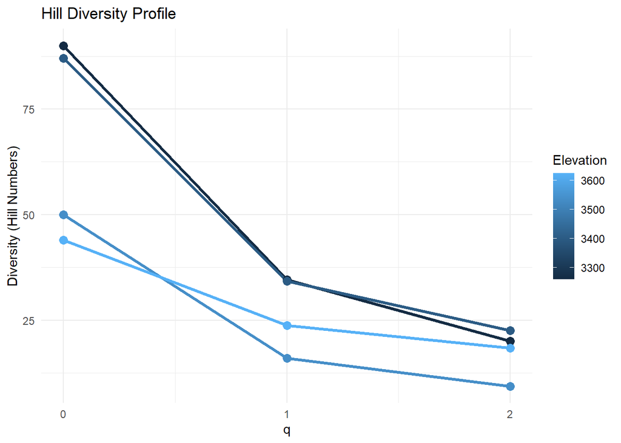

```r
ggplot(HILL_perfil, aes(x = q, y = Valor, color = elevation, group = elevation)) +
  geom_line(size = 1.2) +
  geom_point(size = 3) +
  scale_x_continuous(breaks = c(0,1,2)) +
  labs(title = "Hill Diversity Profile",
       x = "q",
       y = "Diversity (Hill Numbers)",
       color = "Elevation") +
  theme_minimal()
```

BETA DIVERSITY Matrix of abundance

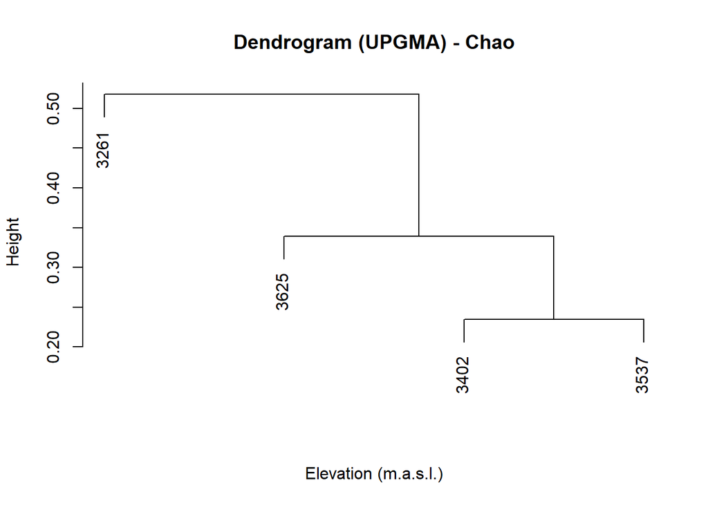

```r
matriz_num <- as.data.frame(matriz)
rownames(matriz_num) <- matriz_num$elevation    # Poner la columna 'elevation' como rownames
matriz_num$elevation <- NULL                    # Quitar columna 'elevation'
dist_chao <- vegdist(matriz_num, method="chao")
hc <- hclust(dist_chao, method="average")

####DENDROGRAMA
plot(hc, main="Dendrogram (UPGMA) - Chao", #UPGMA= metodo de agrupamiento para construir el dendograma
     xlab="Elevation (m.a.s.l.)",     sub="")
```

```r
####NMDS y PCoA
# 1) NMDS
dist_chao <- vegdist(matriz_num, method = "chao")
nmds <- metaMDS(dist_chao, k = 2, trymax = 100)
```

```
## *** Best solution was not repeated -- monoMDS stopping criteria:
##    100: stress < smin
```

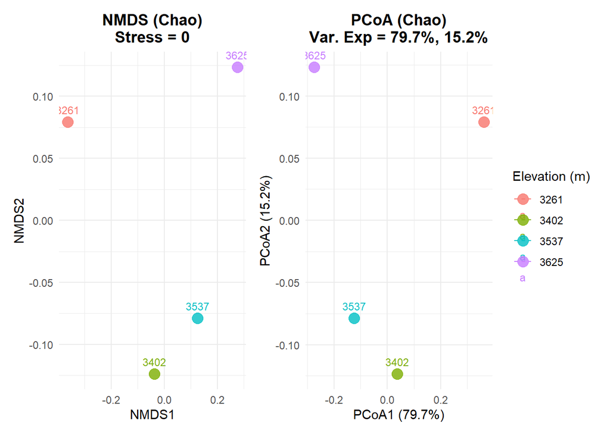

```r
nmds_points <- as.data.frame(nmds$points)
colnames(nmds_points) <- c("NMDS1", "NMDS2")
nmds_points$elevation <- rownames(nmds_points)

plot_nmds <- ggplot(nmds_points, aes(x = NMDS1, y = NMDS2, color = elevation)) +
  geom_point(size = 4, alpha = 0.8) +
  geom_text(aes(label = elevation), vjust = -1, size = 3) +
  stat_ellipse(type = "t", linetype = 2) +
  labs(
    title = paste0("NMDS (Chao)\nStress = ", round(nmds$stress, 3)),
    x = "NMDS1", y = "NMDS2",
    color = "Elevation (m)"
  ) +
  theme_minimal() +
  theme(legend.position = "none",
        plot.title = element_text(hjust = 0.5, face = "bold"))
# 2) PCoA
pcoa <- cmdscale(dist_chao, eig = TRUE, k = 2)
pcoa_points <- as.data.frame(pcoa$points)
colnames(pcoa_points) <- c("PCoA1", "PCoA2")
pcoa_points$elevation <- rownames(pcoa_points)
plot_pcoa <- ggplot(pcoa_points, aes(x = PCoA1, y = PCoA2, color = elevation)) +
  geom_point(size = 4, alpha = 0.8) +
  geom_text(aes(label = elevation), vjust = -1, size = 3) +
  stat_ellipse(type = "t", linetype = 2) +
  labs(
    title = paste0(
      "PCoA (Chao)\nVar. Exp = ",
      round(pcoa$eig[1] / sum(pcoa$eig) * 100, 1), "%, ",
      round(pcoa$eig[2] / sum(pcoa$eig) * 100, 1), "%"
    ),
    x = paste0("PCoA1 (", round(pcoa$eig[1] / sum(pcoa$eig) * 100, 1), "%)"),
    y = paste0("PCoA2 (", round(pcoa$eig[2] / sum(pcoa$eig) * 100, 1), "%)"),
    color = "Elevation (m)"
  ) +
  theme_minimal() +
  theme(plot.title = element_text(hjust = 0.5, face = "bold"))
# 3) Gráfico combinado
plot_nmds + plot_pcoa
```

Beta diversidad global (Whittaker 1960, 1972) 1. Alpha promedio (alpha_mean) Calcula la riqueza promedio de especies por parcela. Es básicamente el promedio de cuántas especies tiene cada comunidad. 2. Gamma (gamma_total) Es la riqueza total regional: el número total de especies considerando todas las parcelas juntas. Equivale al tamaño del pool de especies de la región. 3. Beta multiplicativa (beta_mult) Interpreta cuántas veces más grande es la diversidad regional comparada con la local promedio. Ejemplo: si sale 4, significa que la diversidad regional es 4 veces la riqueza promedio de una parcela. 4. Beta aditiva (beta_add) Representa la diferencia absoluta entre la riqueza regional y la local promedio. Ejemplo: si gamma = 120 especies y alpha promedio = 30, entonces beta aditiva = 90 → hay 90 especies que en promedio no se encuentran en cada comunidad.

```r
# Alpha promedio (riqueza por parcela)
alpha_mean <- mean(specnumber(matriz_num))

# Gamma (riqueza regional total)
gamma_total <- specnumber(colSums(matriz_num > 0))

# Beta multiplicativa y aditiva
beta_mult  <- gamma_total / alpha_mean
beta_add   <- gamma_total - alpha_mean

list(alpha_mean = alpha_mean,
     gamma = gamma_total,
     beta_multiplicative = beta_mult,
     beta_additive = beta_add)
```

```
## $alpha_mean
## [1] 67.75
##
## $gamma
## [1] 158
##
## $beta_multiplicative
## [1] 2.332103
##
## $beta_additive
## [1] 90.25
```

Matrix of presence-absence

```r
matriz_pa <- (matriz_num > 0) * 1   # 1) Transformar a presencia/ausencia
dist_jaccard_pa <- vegdist(matriz_pa, method = "jaccard") # 2) Distancia Bray-Curtis
# 3) NMDS con matriz PA
nmds_pa <- metaMDS(dist_jaccard_pa, k = 2, trymax = 100)
```

```
## *** Best solution was not repeated -- monoMDS stopping criteria:
##    100: stress < smin
```

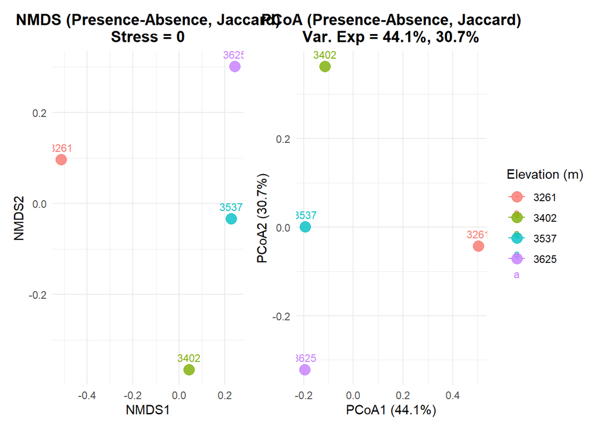

```r
nmds_points_pa <- as.data.frame(nmds_pa$points)
colnames(nmds_points_pa) <- c("NMDS1", "NMDS2")
nmds_points_pa$elevation <- rownames(nmds_points_pa)

plot_nmds_pa <- ggplot(nmds_points_pa, aes(x = NMDS1, y = NMDS2, color = elevation)) +
  geom_point(size = 4, alpha = 0.8) +
  geom_text(aes(label = elevation), vjust = -1, size = 3) +
  stat_ellipse(type = "t", linetype = 2) +
  labs(
    title = paste0("NMDS (Presence-Absence, Jaccard)\nStress = ", round(nmds_pa$stress, 3)),
    x = "NMDS1", y = "NMDS2",
    color = "Elevation (m)"
  ) +
  theme_minimal() +
  theme(legend.position = "none",
        plot.title = element_text(hjust = 0.5, face = "bold"))
# 4) PCoA con matriz PA
pcoa_pa <- cmdscale(dist_jaccard_pa, eig = TRUE, k = 2)

pcoa_points_pa <- as.data.frame(pcoa_pa$points)
colnames(pcoa_points_pa) <- c("PCoA1", "PCoA2")
pcoa_points_pa$elevation <- rownames(pcoa_points_pa)

plot_pcoa_pa <- ggplot(pcoa_points_pa, aes(x = PCoA1, y = PCoA2, color = elevation)) +
  geom_point(size = 4, alpha = 0.8) +
  geom_text(aes(label = elevation), vjust = -1, size = 3) +
  stat_ellipse(type = "t", linetype = 2) +
  labs(
    title = paste0(
      "PCoA (Presence-Absence, Jaccard)\nVar. Exp = ",
      round(pcoa_pa$eig[1] / sum(pcoa_pa$eig) * 100, 1), "%, ",
      round(pcoa_pa$eig[2] / sum(pcoa_pa$eig) * 100, 1), "%"
    ),
    x = paste0("PCoA1 (", round(pcoa_pa$eig[1] / sum(pcoa_pa$eig) * 100, 1), "%)"),
    y = paste0("PCoA2 (", round(pcoa_pa$eig[2] / sum(pcoa_pa$eig) * 100, 1), "%)"),
    color = "Elevation (m)"
  ) +
  theme_minimal() +
  theme(plot.title = element_text(hjust = 0.5, face = "bold"))
# 5) Gráfico combinado
plot_nmds_pa + plot_pcoa_pa
```

PCOA and NMDS IN UNIQUE GRAPHIC

```r
library(vegan)
library(ggplot2)
library(patchwork)

# --- MATRIZ DE ABUNDANCIA ---
matriz_num <- as.data.frame(matriz)
rownames(matriz_num) <- matriz_num$elevation
matriz_num$elevation <- NULL

# --- DISTANCIA CHAO ---
dist_chao <- vegdist(matriz_num, method = "chao")

# --- NMDS CHAO ---
nmds <- metaMDS(dist_chao, k = 2, trymax = 100)
```

```
## *** Best solution was not repeated -- monoMDS stopping criteria:
##    100: stress < smin
```

```r
nmds_points <- as.data.frame(nmds$points)
colnames(nmds_points) <- c("NMDS1", "NMDS2")
nmds_points$elevation <- rownames(nmds_points)

plot_nmds <- ggplot(nmds_points, aes(NMDS1, NMDS2, color = elevation)) +
  geom_point(size = 4, alpha = 0.8) +
  geom_text(aes(label = elevation), vjust = -1, size = 2) +
  stat_ellipse(type = "t", linetype = 2) +
  labs(
    title = paste0("NMDS (Chao)\nStress = ", round(nmds$stress, 3)),
    x = "NMDS1", y = "NMDS2"
  ) +
  theme_minimal(base_size = 10) +
  theme(plot.title = element_text(hjust = 0.5, face = "bold"))

# --- PCoA CHAO ---
pcoa <- cmdscale(dist_chao, eig = TRUE, k = 2)
pcoa_points <- as.data.frame(pcoa$points)
colnames(pcoa_points) <- c("PCoA1", "PCoA2")
pcoa_points$elevation <- rownames(pcoa_points)

plot_pcoa <- ggplot(pcoa_points, aes(PCoA1, PCoA2, color = elevation)) +
  geom_point(size = 4, alpha = 0.8) +
  geom_text(aes(label = elevation), vjust = -1, size = 2) +
  stat_ellipse(type = "t", linetype = 2) +
  labs(
    title = paste0("PCoA (Chao)\nVar. Exp = ",
      round(pcoa$eig[1] / sum(pcoa$eig) * 100, 1), "%, ",
      round(pcoa$eig[2] / sum(pcoa$eig) * 100, 1), "%"
    ),
    x = paste0("PCoA1 (", round(pcoa$eig[1] / sum(pcoa$eig) * 100, 1), "%)"),
    y = paste0("PCoA2 (", round(pcoa$eig[2] / sum(pcoa$eig) * 100, 1), "%)")
  ) +
  theme_minimal(base_size = 10) +
  theme(plot.title = element_text(hjust = 0.5, face = "bold"))

# --- MATRIZ PRESENCIA-AUSENCIA ---
matriz_pa <- (matriz_num > 0) * 1
dist_jaccard_pa <- vegdist(matriz_pa, method = "jaccard")

# --- NMDS JACCARD ---
nmds_pa <- metaMDS(dist_jaccard_pa, k = 2, trymax = 100)
```

```
## *** Best solution was not repeated -- monoMDS stopping criteria:
##    100: stress < smin
```

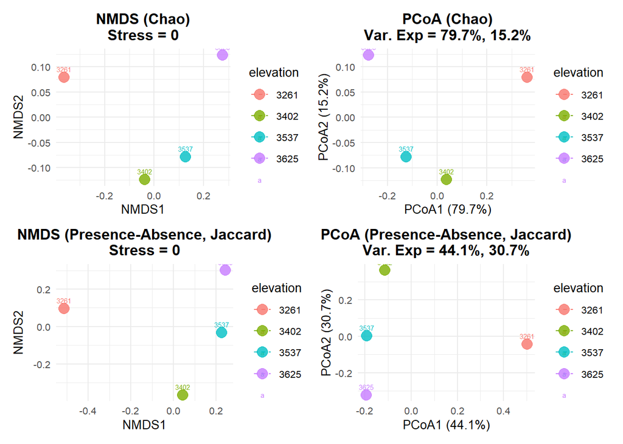

```r
nmds_points_pa <- as.data.frame(nmds_pa$points)
colnames(nmds_points_pa) <- c("NMDS1", "NMDS2")
nmds_points_pa$elevation <- rownames(nmds_points_pa)

plot_nmds_pa <- ggplot(nmds_points_pa, aes(NMDS1, NMDS2, color = elevation)) +
  geom_point(size = 4, alpha = 0.8) +
  geom_text(aes(label = elevation), vjust = -1, size = 2) +
  stat_ellipse(type = "t", linetype = 2) +
  labs(
    title = paste0("NMDS (Presence-Absence, Jaccard)\nStress = ", round(nmds_pa$stress, 3)),
    x = "NMDS1", y = "NMDS2"
  ) +
  theme_minimal(base_size = 10) +
  theme(plot.title = element_text(hjust = 0.5, face = "bold"))

# --- PCoA JACCARD ---
pcoa_pa <- cmdscale(dist_jaccard_pa, eig = TRUE, k = 2)
pcoa_points_pa <- as.data.frame(pcoa_pa$points)
colnames(pcoa_points_pa) <- c("PCoA1", "PCoA2")
pcoa_points_pa$elevation <- rownames(pcoa_points_pa)

plot_pcoa_pa <- ggplot(pcoa_points_pa, aes(PCoA1, PCoA2, color = elevation)) +
  geom_point(size = 4, alpha = 0.8) +
  geom_text(aes(label = elevation), vjust = -1, size = 2) +
  stat_ellipse(type = "t", linetype = 2) +
  labs(
    title = paste0("PCoA (Presence-Absence, Jaccard)\nVar. Exp = ",
      round(pcoa_pa$eig[1] / sum(pcoa_pa$eig) * 100, 1), "%, ",
      round(pcoa_pa$eig[2] / sum(pcoa_pa$eig) * 100, 1), "%"
    ),
    x = paste0("PCoA1 (", round(pcoa_pa$eig[1] / sum(pcoa_pa$eig) * 100, 1), "%)"),
    y = paste0("PCoA2 (", round(pcoa_pa$eig[2] / sum(pcoa_pa$eig) * 100, 1), "%)")
  ) +
  theme_minimal(base_size = 10) +
  theme(plot.title = element_text(hjust = 0.5, face = "bold"))

# --- COMBINAR EN 2x2 CON TÍTULOS POR FILA ---
final_plot <- (
  (plot_nmds + plot_pcoa) +
    plot_annotation(title = "Abundance (Chao)",
                    theme = theme(plot.title = element_text(hjust = 0.5, size = 6, face = "bold")))
) /
(
  (plot_nmds_pa + plot_pcoa_pa) +
    plot_annotation(title = "Presence-ausence (Jaccard)",
                    theme = theme(plot.title = element_text(hjust = 0.5, size = 6, face = "bold")))
)

final_plot
```

GRAPHIC NMDS AND PCoA by phorophyte -abundance matrix

```r
library(vegan)
library(ggplot2)
library(dplyr)
library(patchwork)

ABUNDFO <- data %>%               #tabla de abundancias por plot/ELEVATION
  group_by(forof, morphospe) %>%
  summarise(ABUNDANCIA = n(), .groups = "drop") %>%
  arrange(forof, desc(ABUNDANCIA))
matrizf <- ABUNDFO %>%              #matriz de abundancias
  pivot_wider(
    names_from = morphospe,
    values_from = ABUNDANCIA,
    values_fill = 0
  )
names(matrizf)
```

```
##   [1] "forof"                        "Ascogrammitis_athyrioides"
##   [3] "Campyloneurum_densifolium"    "Elaphoglossum_vulcanicum"
##   [5] "Hymenophyllum_sp1"            "Asplenium_fragans"
##   [7] "Melpomene_personata"          "Peperomia_sp1"
##   [9] "Serpocaulon_sp2"              "Elaphoglossum_sp20"
##  [11] "Melpomene_sp10"               "Elaphoglossum_sp19"
##  [13] "Demosthenesia_spectabilis"    "Elaphoglossum_metallicum"
##  [15] "Epidendrum_sp2"               "Pachyphyllum_sp1"
##  [17] "Radiovittaria_ruizziana"      "Epidendrum_sp3"
##  [19] "Pleurothallis_sp2"            "Demosthenesia_buxifolia"
##  [21] "Lepanthopsis_acuminata"       "Pleurothallis_sp1"
##  [23] "Epidendrum_sp4"               "Racinaea_seemannii"
##  [25] "Siphonandra_elliptica"        "Lepanthes_sp2"
##  [27] "Lepanthes_sp1"                "Disterigma_alaternoides"
##  [29] "Elaphoglossum_muscosum"       "Stelis_simplex"
```

[output cut: 65 more lines]

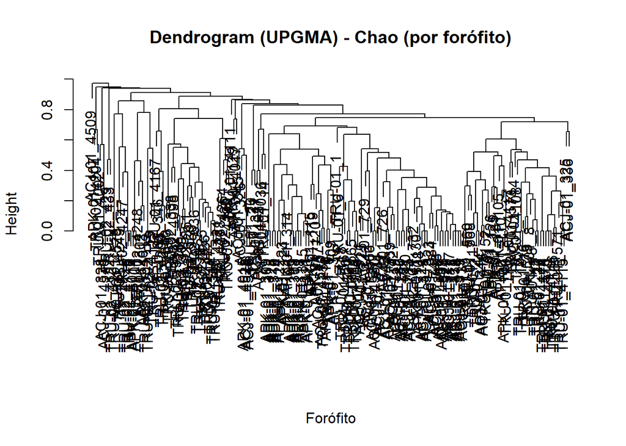

```r
forofito <- matrizf$forof   # 1. Guardamos los nombres de los plots
matrizfo_num <- matrizf %>% select(-forof)
# --- 1. Preparar matriz de abundancia por forófito ---
matriz_forof <- matrizf %>%
  group_by(forof) %>%                     # agrupar por forófito
  summarise(across(where(is.numeric), sum)) %>%  # sumar abundancias por especie
  as.data.frame()

rownames(matriz_forof) <- matriz_forof$forof
matriz_forof$forof <- NULL

# --- 2. Calcular distancia Chao ---
dist_chao <- vegdist(matriz_forof, method = "chao")

# --- 3. Dendrograma ---
hc <- hclust(dist_chao, method = "average")
plot(
  hc,
  main = "Dendrogram (UPGMA) - Chao (por forófito)",
  xlab = "Forófito",
  sub = ""
)
```

```r
# --- 4. NMDS ---
nmds <- metaMDS(dist_chao, k = 2, trymax = 100)
```

```
## *** Best solution was not repeated -- monoMDS stopping criteria:
##     39: no. of iterations >= maxit
##     61: stress ratio > sratmax
```

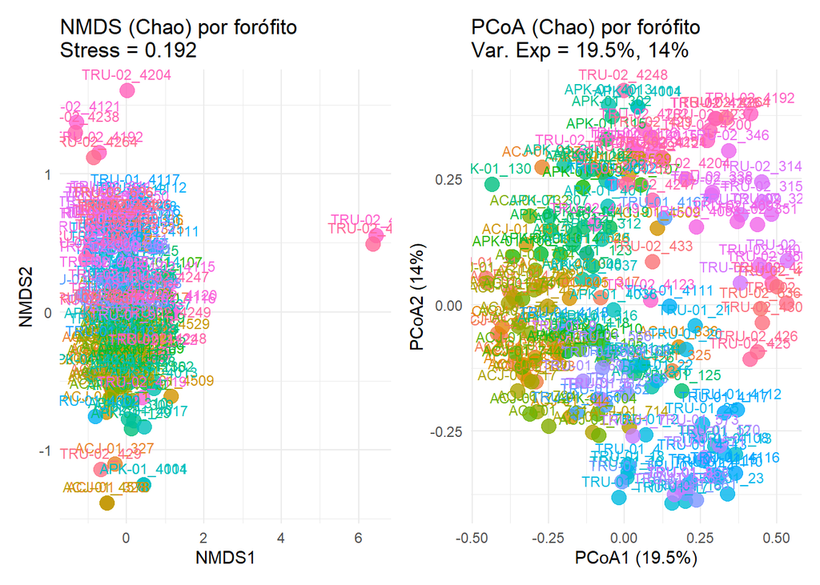

```r
nmds_points <- as.data.frame(nmds$points)
colnames(nmds_points) <- c("NMDS1", "NMDS2")
nmds_points$forof <- rownames(nmds_points)

plot_nmds <- ggplot(nmds_points, aes(x = NMDS1, y = NMDS2, color = forof)) +
  geom_point(size = 4, alpha = 0.8) +
  geom_text(aes(label = forof), vjust = -1, size = 3) +
  stat_ellipse(type = "t", linetype = 2) +
  labs(
    title = paste0("NMDS (Chao) por forófito\nStress = ", round(nmds$stress, 3)),
    x = "NMDS1", y = "NMDS2",
    color = "Forófito"
  ) +
  theme_minimal() +
  theme(legend.position = "none")

# --- 5. PCoA ---
pcoa <- cmdscale(dist_chao, eig = TRUE, k = 2)
pcoa_points <- as.data.frame(pcoa$points)
colnames(pcoa_points) <- c("PCoA1", "PCoA2")
pcoa_points$forof <- rownames(pcoa_points)

plot_pcoa <- ggplot(pcoa_points, aes(x = PCoA1, y = PCoA2, color = forof)) +
  geom_point(size = 4, alpha = 0.8) +
  geom_text(aes(label = forof), vjust = -1, size = 3) +
  stat_ellipse(type = "t", linetype = 2) +
  labs(
    title = paste0(
      "PCoA (Chao) por forófito\nVar. Exp = ",
      round(pcoa$eig[1] / sum(pcoa$eig) * 100, 1), "%, ",
      round(pcoa$eig[2] / sum(pcoa$eig) * 100, 1), "%"
    ),
    x = paste0("PCoA1 (", round(pcoa$eig[1] / sum(pcoa$eig) * 100, 1), "%)"),
    y = paste0("PCoA2 (", round(pcoa$eig[2] / sum(pcoa$eig) * 100, 1), "%)"),
    color = "Forófito"
  ) +
  theme_minimal() +
  theme(legend.position = "none")

# --- 6. Combinar NMDS y PCoA ---
plot_nmds + plot_pcoa
```

Components of Beta Diversity

```r
## Para matriz de presencia ausencia
matriz_pa <- (matriz_num > 0) * 1  # 1) Matriz de presencia/ausencia
beta_pa <- beta.pair(matriz_pa, index.family = "sorensen")# 2) Calcular componentes de beta diversidad
# Esto devuelve tres matrices de disimilitud:
# $beta.sim  = turnover (reemplazo)
# $beta.sne  = nestedness (anidamiento)
# $beta.sor  = beta total (Sorensen)
beta_summary <- data.frame(      # 3) Calcular promedio de cada componente
  Beta_total   = mean(beta_pa$beta.sor),
  Turnover     = mean(beta_pa$beta.sim),
  Nestedness   = mean(beta_pa$beta.sne)
)
print(beta_summary)
```

```
##   Beta_total  Turnover Nestedness
## 1  0.5592395 0.4251689  0.1340706
```

```r
#Para Matriz de abundancias
matriz_ab <- as.data.frame(matriz_num)
beta_abund <- beta.pair.abund(matriz_ab, index.family = "bray")# 2) Calcular los componentes de la beta diversidad de abundancia
# Esto devuelve tres matrices de disimilitud:
# $beta.bray.bal = reemplazo (balanced variation in abundance)
# $beta.bray.gra = gradiente (abundance gradients)
# $beta.bray     = beta total (Bray-Curtis)

beta_abund_summary <- data.frame( # 3) Promedio de cada componente
  Beta_total   = mean(beta_abund$beta.bray),
  Replacement  = mean(beta_abund$beta.bray.bal),
  Gradient     = mean(beta_abund$beta.bray.gra)
)
print(beta_abund_summary)
```

```
##   Beta_total Replacement  Gradient
## 1  0.6393731   0.5417435 0.0976296
```